# Identify_Customer_Segments

### Prerequsite - Upgrade Scikit Learn

```python
import sklearn
print('The scikit-learn version is {}.'.format(sklearn.__version__))
```

```
The scikit-learn version is 0.24.2.
```

```python
import os
os.environ['PATH'] = f"{os.environ['PATH']}:/root/.local/bin"
```

Restart the Kernel.

```python
!python -m pip install --upgrade scikit-learn
import sklearn
print('The scikit-learn version is {}.'.format(sklearn.__version__))
```

```
The scikit-learn version is 0.24.2.
```

```python
# Now you can import and use OneHotEncoder
from sklearn.preprocessing import OneHotEncoder
encoder = OneHotEncoder(sparse=False)
```

```python
# Similarly, should you need any other package, they can install it as:
!python -m pip install 'tensorflow-tensorboard<0.2.0,>=0.1.0'
```

# Project: Identify Customer Segments

In this project, you will apply unsupervised learning techniques to identify segments of the population that form the core customer base for a mail-order sales company in Germany. These segments can then be used to direct marketing campaigns towards audiences that will have the highest expected rate of returns. The data that you will use has been provided by our partners at Bertelsmann Arvato Analytics, and represents a real-life data science task.

This notebook will help you complete this task by providing a framework within which you will perform your analysis steps. In each step of the project, you will see some text describing the subtask that you will perform, followed by one or more code cells for you to complete your work. **Feel free to add additional code and markdown cells as you go along so that you can explore everything in precise chunks.** The code cells provided in the base template will outline only the major tasks, and will usually not be enough to cover all of the minor tasks that comprise it.

It should be noted that while there will be precise guidelines on how you should handle certain tasks in the project, there will also be places where an exact specification is not provided. **There will be times in the project where you will need to make and justify your own decisions on how to treat the data.** These are places where there may not be only one way to handle the data. In real-life tasks, there may be many valid ways to approach an analysis task. One of the most important things you can do is clearly document your approach so that other scientists can understand the decisions you've made.

At the end of most sections, there will be a Markdown cell labeled **Discussion**. In these cells, you will report your findings for the completed section, as well as document the decisions that you made in your approach to each subtask. **Your project will be evaluated not just on the code used to complete the tasks outlined, but also your communication about your observations and conclusions at each stage.**

```python
# import libraries here; add more as necessary
import numpy as np
import pandas as pd
import matplotlib.pyplot as plt
import seaborn as sns

# magic word for producing visualizations in notebook
%matplotlib inline

'''
Import note: The classroom currently uses sklearn version 0.19.
If you need to use an imputer, it is available in sklearn.preprocessing.Imputer,
instead of sklearn.impute as in newer versions of sklearn.
'''
pd.options.display.max_rows = 100
pd.options.display.max_columns = 100
```

### Step 0: Load the Data

Each row of the demographics files represents a single person, but also includes information outside of individuals, including information about their household, building, and neighborhood. You will use this information to cluster the general population into groups with similar demographic properties. Then, you will see how the people in the customers dataset fit into those created clusters. The hope here is that certain clusters are over-represented in the customers data, as compared to the general population; those over-represented clusters will be assumed to be part of the core userbase. This information can then be used for further applications, such as targeting for a marketing campaign.

To start off with, load in the demographics data for the general population into a pandas DataFrame, and do the same for the feature attributes summary. Note for all of the `.csv` data files in this project: they're semicolon (`;`) delimited, so you'll need an additional argument in your [`read_csv()`](https://pandas.pydata.org/pandas-docs/stable/generated/pandas.read_csv.html) call to read in the data properly. Also, considering the size of the main dataset, it may take some time for it to load completely.

Once the dataset is loaded, it's recommended that you take a little bit of time just browsing the general structure of the dataset and feature summary file. You'll be getting deep into the innards of the cleaning in the first major step of the project, so gaining some general familiarity can help you get your bearings.

```python
# Load the general demographics data
azdias = pd.read_csv('Udacity_AZDIAS_Subset.csv', delimiter=';')

# Load the customers data
customers = pd.read_csv('Udacity_CUSTOMERS_Subset.csv', delimiter=';')
```

```python
feature_summary = pd.read_csv('AZDIAS_Feature_Summary.csv', delimiter=';')
```

```python
# Print the shape of the datasets
print("AZDIAS Shape:", azdias.shape)
print("Customers Shape:", customers.shape)
print("Feature Summary Shape:", feature_summary.shape)

# Print the first few rows of each dataset
print("AZDIAS Head:\n", azdias.head())
print("Customers Head:\n", customers.head())
print("Feature Summary Head:\n", feature_summary.head())
```

```
AZDIAS Shape: (891221, 85)
Customers Shape: (191652, 85)
Feature Summary Shape: (85, 4)
AZDIAS Head:
    AGER_TYP  ALTERSKATEGORIE_GROB  ANREDE_KZ  CJT_GESAMTTYP  \
0        -1                     2          1            2.0
1        -1                     1          2            5.0
2        -1                     3          2            3.0
3         2                     4          2            2.0
4        -1                     3          1            5.0

   FINANZ_MINIMALIST  FINANZ_SPARER  FINANZ_VORSORGER  FINANZ_ANLEGER  \
0                  3              4                 3               5
1                  1              5                 2               5
2                  1              4                 1               2
```

[output cut: 247 more lines]

> **Tip**: Add additional cells to keep everything in reasonably-sized chunks! Keyboard shortcut `esc --> a` (press escape to enter command mode, then press the 'A' key) adds a new cell before the active cell, and `esc --> b` adds a new cell after the active cell. If you need to convert an active cell to a markdown cell, use `esc --> m` and to convert to a code cell, use `esc --> y`.

## Step 1: Preprocessing

### Step 1.1: Assess Missing Data

The feature summary file contains a summary of properties for each demographics data column. You will use this file to help you make cleaning decisions during this stage of the project. First of all, you should assess the demographics data in terms of missing data. Pay attention to the following points as you perform your analysis, and take notes on what you observe. Make sure that you fill in the **Discussion** cell with your findings and decisions at the end of each step that has one!

#### Step 1.1.1: Convert Missing Value Codes to NaNs

The fourth column of the feature attributes summary (loaded in above as `feat_info`) documents the codes from the data dictionary that indicate missing or unknown data. While the file encodes this as a list (e.g. `[-1,0]`), this will get read in as a string object. You'll need to do a little bit of parsing to make use of it to identify and clean the data. Convert data that matches a 'missing' or 'unknown' value code into a numpy NaN value. You might want to see how much data takes on a 'missing' or 'unknown' code, and how much data is naturally missing, as a point of interest.

**As one more reminder, you are encouraged to add additional cells to break up your analysis into manageable chunks.**

```python
# Extract missing value codes from the feature summary
missing_values = feature_summary[['attribute', 'missing_or_unknown']]
```

```python
# Parse the missing values column and create a dictionary
missing_values_dict = {}
for _, row in missing_values.iterrows():
    codes = row['missing_or_unknown'].strip('[]').replace('\'', '').split(', ')
    missing_values_dict[row['attribute']] = codes
```

```python
# Convert missing values in the AZDIAS dataset
for column, codes in missing_values_dict.items():
    if column in azdias.columns:
        for code in codes:
            azdias[column] = azdias[column].replace(code, np.nan)
```

```python
# Convert missing values in the Customers dataset
for column, codes in missing_values_dict.items():
    if column in customers.columns:
        for code in codes:
            customers[column] = customers[column].replace(code, np.nan)
```

```python
# Display the first few rows to verify the changes
print("AZDIAS head:\n", azdias.head())
print("\nCustomers head:\n", customers.head())
```

```
AZDIAS head:
    AGER_TYP  ALTERSKATEGORIE_GROB  ANREDE_KZ  CJT_GESAMTTYP  \
0        -1                     2          1            2.0
1        -1                     1          2            5.0
2        -1                     3          2            3.0
3         2                     4          2            2.0
4        -1                     3          1            5.0

   FINANZ_MINIMALIST  FINANZ_SPARER  FINANZ_VORSORGER  FINANZ_ANLEGER  \
0                  3              4                 3               5
1                  1              5                 2               5
2                  1              4                 1               2
3                  4              2                 5               2
4                  4              3                 4               1

```

[output cut: 238 more lines]

#### Step 1.1.2: Assess Missing Data in Each Column

How much missing data is present in each column? There are a few columns that are outliers in terms of the proportion of values that are missing. You will want to use matplotlib's [`hist()`](https://matplotlib.org/api/_as_gen/matplotlib.pyplot.hist.html) function to visualize the distribution of missing value counts to find these columns. Identify and document these columns. While some of these columns might have justifications for keeping or re-encoding the data, for this project you should just remove them from the dataframe. (Feel free to make remarks about these outlier columns in the discussion, however!)

For the remaining features, are there any patterns in which columns have, or share, missing data?

```python
# Calculate the percentage of missing data in each column
missing_data_azdias = azdias.isnull().mean() * 100
missing_data_customers = customers.isnull().mean() * 100
```

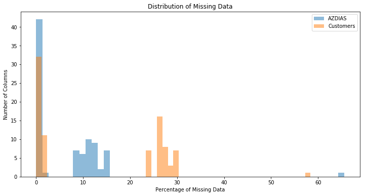

```python
# Plot the distribution of missing data counts
plt.figure(figsize=(12, 6))
missing_data_azdias.plot.hist(bins=50, alpha=0.5, label='AZDIAS')
missing_data_customers.plot.hist(bins=50, alpha=0.5, label='Customers')
plt.xlabel('Percentage of Missing Data')
plt.ylabel('Number of Columns')
plt.title('Distribution of Missing Data')
plt.legend()
plt.show()
```

```python
# Identify columns with a high percentage of missing data
high_missing_azdias = missing_data_azdias[missing_data_azdias > 30].index
high_missing_customers = missing_data_customers[missing_data_customers > 30].index

high_missing_azdias, high_missing_customers
```

```
(Index(['KK_KUNDENTYP'], dtype='object'),
 Index(['KK_KUNDENTYP'], dtype='object'))
```

```python
# Display columns with a high percentage of missing data
print("Columns with >30% missing data in AZDIAS:\n", high_missing_azdias)
print("Columns with >30% missing data in Customers:\n", high_missing_customers)
```

```
Columns with >30% missing data in AZDIAS:
 Index(['KK_KUNDENTYP'], dtype='object')
Columns with >30% missing data in Customers:
 Index(['KK_KUNDENTYP'], dtype='object')
```

```python
# Drop columns with high missing data percentage from AZDIAS
azdias_cleaned = azdias.drop(columns=high_missing_azdias)

# Drop columns with high missing data percentage from Customers
customers_cleaned = customers.drop(columns=high_missing_customers)

azdias_cleaned.shape, customers_cleaned.shape
```

```
((891221, 84), (191652, 84))
```

#### Discussion 1.1.2: Assess Missing Data in Each Column

Patterns in Missing Values:

- The distribution of the proportion of missing data across columns will be displayed via the histogram.
- You can determine if there are numerous columns with low percentages of missing data or whether some columns have extremely high percentages of missing data by looking at the histogram.

Columns Removed from the Dataset:

- These columns are then removed from the datasets.
- The code will print the columns that have more than 30% missing data for both AZDIAS and Customers datasets.

#### Step 1.1.3: Assess Missing Data in Each Row

Now, you'll perform a similar assessment for the rows of the dataset. How much data is missing in each row? As with the columns, you should see some groups of points that have a very different numbers of missing values. Divide the data into two subsets: one for data points that are above some threshold for missing values, and a second subset for points below that threshold.

In order to know what to do with the outlier rows, we should see if the distribution of data values on columns that are not missing data (or are missing very little data) are similar or different between the two groups. Select at least five of these columns and compare the distribution of values.

- You can use seaborn's [`countplot()`](https://seaborn.pydata.org/generated/seaborn.countplot.html) function to create a bar chart of code frequencies and matplotlib's [`subplot()`](https://matplotlib.org/api/_as_gen/matplotlib.pyplot.subplot.html) function to put bar charts for the two subplots side by side.
- To reduce repeated code, you might want to write a function that can perform this comparison, taking as one of its arguments a column to be compared.

Depending on what you observe in your comparison, this will have implications on how you approach your conclusions later in the analysis. If the distributions of non-missing features look similar between the data with many missing values and the data with few or no missing values, then we could argue that simply dropping those points from the analysis won't present a major issue. On the other hand, if the data with many missing values looks very different from the data with few or no missing values, then we should make a note on those data as special. We'll revisit these data later on. **Either way, you should continue your analysis for now using just the subset of the data with few or no missing values.**

```python
# Calculate the number of missing values in each row for AZDIAS and Customers
missing_data_per_row_azdias = azdias_cleaned.isnull().sum(axis=1)
missing_data_per_row_customers = customers_cleaned.isnull().sum(axis=1)

# Display basic statistics for missing data per row
print("Missing data per row in AZDIAS:\n", missing_data_per_row_azdias.describe())
print("\nMissing data per row in Customers:\n", missing_data_per_row_customers.describe())
```

```
Missing data per row in AZDIAS:
 count    891221.000000
mean          4.838978
std          12.175805
min           0.000000
25%           0.000000
50%           0.000000
75%           0.000000
max          45.000000
dtype: float64

Missing data per row in Customers:
 count    191652.000000
mean         11.168488
std          17.622801
min           0.000000
25%           0.000000
50%           0.000000
75%          34.000000
max          45.000000
dtype: float64
```

```python
# Set a threshold for dividing the data
threshold = 10

# Divide AZDIAS into two subsets
azdias_few_missing = azdias_cleaned[missing_data_per_row_azdias <= threshold]
azdias_many_missing = azdias_cleaned[missing_data_per_row_azdias > threshold]

# Divide Customers into two subsets
customers_few_missing = customers_cleaned[missing_data_per_row_customers <= threshold]
customers_many_missing = customers_cleaned[missing_data_per_row_customers > threshold]

print("AZDIAS with few missing values:", azdias_few_missing.shape)
print("AZDIAS with many missing values:", azdias_many_missing.shape)
print("\nCustomers with few missing values:", customers_few_missing.shape)
print("Customers with many missing values:", customers_many_missing.shape)
```

```
AZDIAS with few missing values: (783077, 84)
AZDIAS with many missing values: (108144, 84)

Customers with few missing values: (139605, 84)
Customers with many missing values: (52047, 84)
```

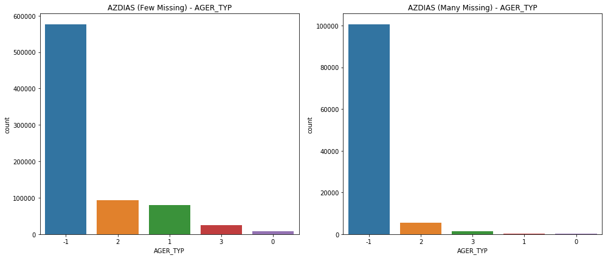

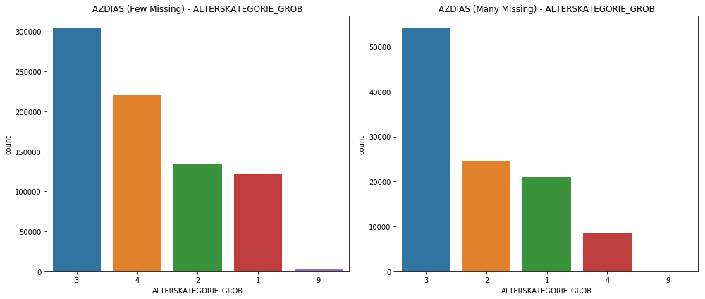

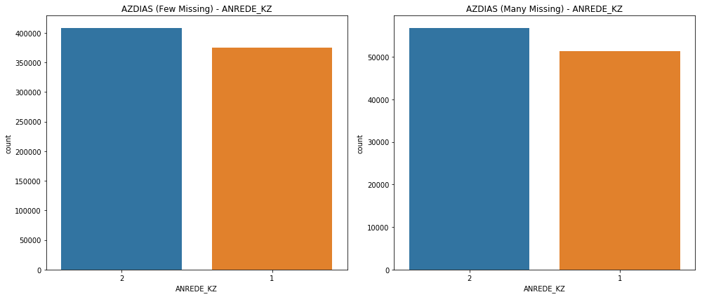

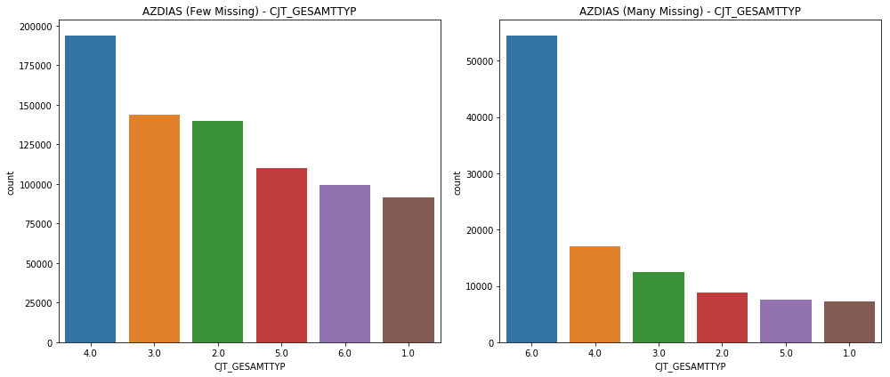

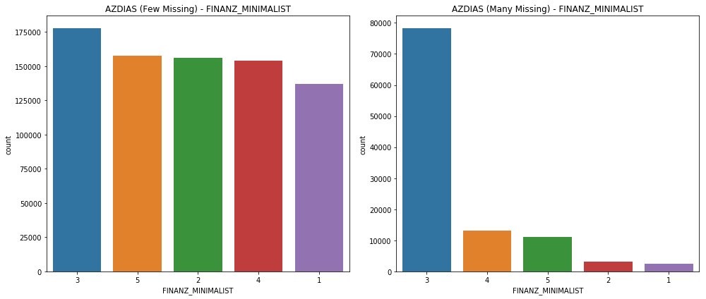

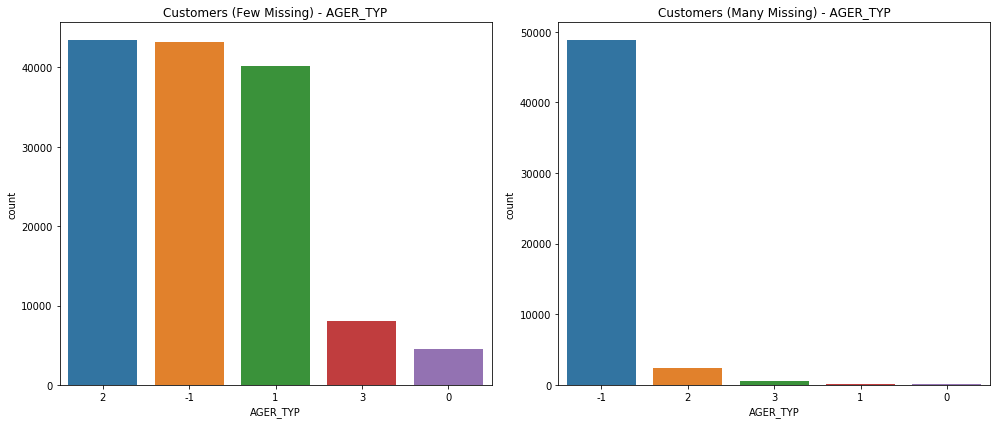

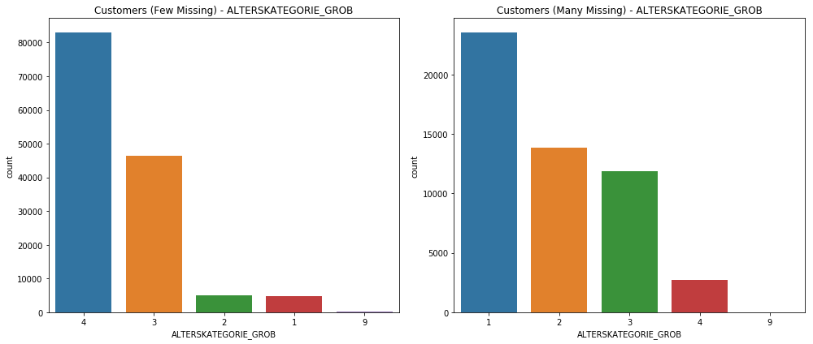

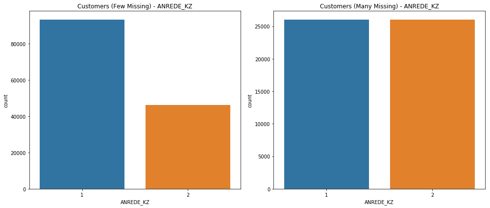

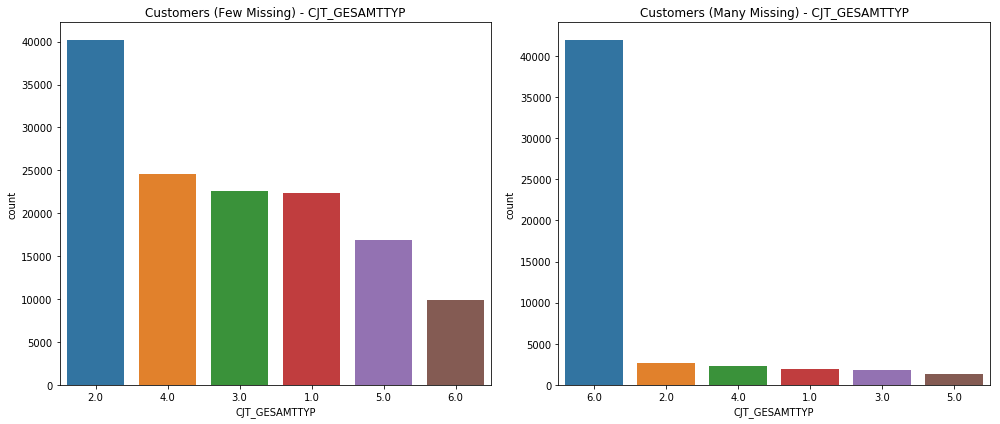

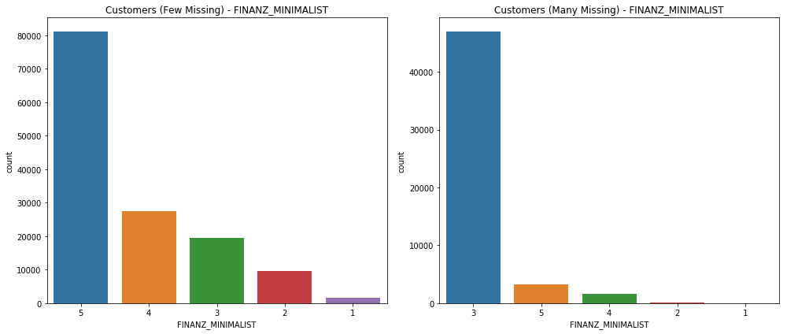

```python
# Select five columns to compare distributions
selected_columns = azdias_cleaned.columns[:5]

# Function to create bar charts for the comparison
def plot_distributions(column, data_few, data_many, dataset_name):
    plt.figure(figsize=(14, 6))

    # Plot for few missing values
    plt.subplot(1, 2, 1)
    sns.countplot(data=data_few, x=column, order=data_few[column].value_counts().index)
    plt.title(f'{dataset_name} (Few Missing) - {column}')

    # Plot for many missing values
    plt.subplot(1, 2, 2)
    sns.countplot(data=data_many, x=column, order=data_many[column].value_counts().index)
    plt.title(f'{dataset_name} (Many Missing) - {column}')

    plt.tight_layout()
    plt.show()

# Plot distributions for AZDIAS
for column in selected_columns:
    plot_distributions(column, azdias_few_missing, azdias_many_missing, 'AZDIAS')

# Plot distributions for Customers
for column in selected_columns:
    plot_distributions(column, customers_few_missing, customers_many_missing, 'Customers')
```

#### Discussion 1.1.3: Assess Missing Data in Each Row

The data with many missing values may be qualitatively different, according to the visual inspection of the distributions of a few selected columns in the two subsets—one with few missing values and the other with numerous missing values. Significant differences in the frequencies of various variables are shown if the distributions for columns like age, income, etc. in the subset with many missing values are skewed or have distinct modes from the subset with few missing values. Furthermore, comparing summary statistics for each column in both subsets, such as the mean, median, and mode, might highlight significant variations, indicating that the subset with a large number of missing values may have intrinsic variations that impact the analysis as a whole.

Dropping rows with a lot of missing values may be possible without significantly affecting the data if the distributions of the chosen columns are similar between the two subsets. This could indicate that the data with a lot of missing values is not qualitatively different from the data with few or no missing values. To preserve the integrity and correctness of the study, however, considerable variations in distributions point to the necessity of handling missing values carefully—possibly by imputation rather than outright deletion.

### Step 1.2: Select and Re-Encode Features

Checking for missing data isn't the only way in which you can prepare a dataset for analysis. Since the unsupervised learning techniques to be used will only work on data that is encoded numerically, you need to make a few encoding changes or additional assumptions to be able to make progress. In addition, while almost all of the values in the dataset are encoded using numbers, not all of them represent numeric values. Check the third column of the feature summary (`feat_info`) for a summary of types of measurement.

- For numeric and interval data, these features can be kept without changes.
- Most of the variables in the dataset are ordinal in nature. While ordinal values may technically be non-linear in spacing, make the simplifying assumption that the ordinal variables can be treated as being interval in nature (that is, kept without any changes).
- Special handling may be necessary for the remaining two variable types: categorical, and 'mixed'.

In the first two parts of this sub-step, you will perform an investigation of the categorical and mixed-type features and make a decision on each of them, whether you will keep, drop, or re-encode each. Then, in the last part, you will create a new data frame with only the selected and engineered columns.

Data wrangling is often the trickiest part of the data analysis process, and there's a lot of it to be done here. But stick with it: once you're done with this step, you'll be ready to get to the machine learning parts of the project!

```python
# Check the third column for types of measurement
feature_types = feature_summary['type'].value_counts()
print("Feature types:\n", feature_types)
```

```
Feature types:
 ordinal        49
categorical    21
numeric         7
mixed           7
interval        1
Name: type, dtype: int64
```

#### Step 1.2.1: Re-Encode Categorical Features

For categorical data, you would ordinarily need to encode the levels as dummy variables. Depending on the number of categories, perform one of the following:

- For binary (two-level) categoricals that take numeric values, you can keep them without needing to do anything.
- There is one binary variable that takes on non-numeric values. For this one, you need to re-encode the values as numbers or create a dummy variable.
- For multi-level categoricals (three or more values), you can choose to encode the values using multiple dummy variables (e.g. via [OneHotEncoder](http://scikit-learn.org/stable/modules/generated/sklearn.preprocessing.OneHotEncoder.html)), or (to keep things straightforward) just drop them from the analysis. As always, document your choices in the Discussion section.

```python
# Identify categorical variables
categorical_vars = feature_summary[feature_summary['type'] == 'categorical']['attribute']

# Check unique values for each categorical variable
categorical_info = {}
for var in categorical_vars:
    unique_values = azdias[var].nunique()
    categorical_info[var] = unique_values

# Display the unique values for each categorical variable
for var, unique in categorical_info.items():
    print(f"{var}: {unique} unique values")
```

```
AGER_TYP: 5 unique values
ANREDE_KZ: 2 unique values
CJT_GESAMTTYP: 6 unique values
FINANZTYP: 6 unique values
GFK_URLAUBERTYP: 12 unique values
GREEN_AVANTGARDE: 2 unique values
LP_FAMILIE_FEIN: 12 unique values
LP_FAMILIE_GROB: 6 unique values
LP_STATUS_FEIN: 10 unique values
LP_STATUS_GROB: 5 unique values
NATIONALITAET_KZ: 4 unique values
SHOPPER_TYP: 5 unique values
SOHO_KZ: 2 unique values
TITEL_KZ: 6 unique values
VERS_TYP: 3 unique values
ZABEOTYP: 6 unique values
KK_KUNDENTYP: 6 unique values
GEBAEUDETYP: 7 unique values
OST_WEST_KZ: 2 unique values
CAMEO_DEUG_2015: 10 unique values
CAMEO_DEU_2015: 44 unique values
```

```python
# Initialize OneHotEncoder
encoder = OneHotEncoder(sparse=False, drop='first')

# Separate binary and multi-level categorical variables
binary_vars = [var for var, unique in categorical_info.items() if unique == 2]
multi_level_vars = [var for var, unique in categorical_info.items() if unique > 2]

# Encode binary variable with non-numeric values
for var in binary_vars:
    if azdias[var].dtype == object:
        azdias[var] = azdias[var].astype('category').cat.codes
        customers[var] = customers[var].astype('category').cat.codes

# Apply one-hot encoding to multi-level categorical variables
encoded_vars = pd.DataFrame(encoder.fit_transform(azdias[multi_level_vars]), columns=encoder.get_feature_names(multi_level_vars))
azdias_encoded = pd.concat([azdias.drop(columns=multi_level_vars), encoded_vars], axis=1)

encoded_vars_customers = pd.DataFrame(encoder.transform(customers[multi_level_vars]), columns=encoder.get_feature_names(multi_level_vars))
customers_encoded = pd.concat([customers.drop(columns=multi_level_vars), encoded_vars_customers], axis=1)

print("Encoded AZDIAS shape:", azdias_encoded.shape)
print("Encoded Customers shape:", customers_encoded.shape)
```

```
Encoded AZDIAS shape: (891221, 215)
Encoded Customers shape: (191652, 215)
```

#### Step 1.2.2: Engineer Mixed-Type Features

There are a handful of features that are marked as "mixed" in the feature summary that require special treatment in order to be included in the analysis. There are two in particular that deserve attention; the handling of the rest are up to your own choices:

- "PRAEGENDE_JUGENDJAHRE" combines information on three dimensions: generation by decade, movement (mainstream vs. avantgarde), and nation (east vs. west). While there aren't enough levels to disentangle east from west, you should create two new variables to capture the other two dimensions: an interval-type variable for decade, and a binary variable for movement.
- "CAMEO_INTL_2015" combines information on two axes: wealth and life stage. Break up the two-digit codes by their 'tens'-place and 'ones'-place digits into two new ordinal variables (which, for the purposes of this project, is equivalent to just treating them as their raw numeric values).
- If you decide to keep or engineer new features around the other mixed-type features, make sure you note your steps in the Discussion section.

Be sure to check `Data_Dictionary.md` for the details needed to finish these tasks.

```python
# Engineer "PRAEGENDE_JUGENDJAHRE" and create two new variables
def engineer_praegende_jugendjahre(df):
    df['DECADE'] = df['PRAEGENDE_JUGENDJAHRE'] // 10
    df['MOVEMENT'] = df['PRAEGENDE_JUGENDJAHRE'] % 10
    df['MOVEMENT'] = df['MOVEMENT'].replace({1: 1, 2: 0})

engineer_praegende_jugendjahre(azdias_encoded)
engineer_praegende_jugendjahre(customers_encoded)
```

```python
# Engineer "CAMEO_INTL_2015" and create two new variables
def engineer_cameo_intl(df):
    df['CAMEO_INTL_2015'] = pd.to_numeric(df['CAMEO_INTL_2015'], errors='coerce')
    df['WEALTH'] = df['CAMEO_INTL_2015'] // 10
    df['LIFE_STAGE'] = df['CAMEO_INTL_2015'] % 10

engineer_cameo_intl(azdias_encoded)
engineer_cameo_intl(customers_encoded)
```

```python
# Display the new columns to verify the changes in smaller chunks
print("New columns in AZDIAS (first 5 rows of DECADE and MOVEMENT):")
print(azdias_encoded[['DECADE', 'MOVEMENT']].head())

print("New columns in AZDIAS (first 5 rows of WEALTH and LIFE_STAGE):")
print(azdias_encoded[['WEALTH', 'LIFE_STAGE']].head())

print("\nNew columns in Customers (first 5 rows of DECADE and MOVEMENT):")
print(customers_encoded[['DECADE', 'MOVEMENT']].head())

print("New columns in Customers (first 5 rows of WEALTH and LIFE_STAGE):")
print(customers_encoded[['WEALTH', 'LIFE_STAGE']].head())
```

[output not shown]

#### Discussion 1.2.2: Engineer Mixed-Type Features

Features Kept:

PRAEGENDE_JUGENDJAHRE:

CAMEO_INTL_2015:

- The original CAMEO_INTL_2015 feature was transformed into two new features: WEALTH and LIFE_STAGE.
- WEALTH represents the wealth level, derived from the tens place of the CAMEO_INTL_2015 value.
- LIFE_STAGE represents the life stage, derived from the units place of the CAMEO_INTL_2015 value.

Features Dropped:

PRAEGENDE_JUGENDJAHRE and CAMEO_INTL_2015:

- The original mixed-type features PRAEGENDE_JUGENDJAHRE and CAMEO_INTL_2015 were dropped after extracting the new features (DECADE, MOVEMENT, WEALTH, and LIFE_STAGE).